# Rasins Quality detection

```python
import numpy as np
import pandas as pd
import matplotlib.pyplot as plt
import seaborn as sns
from sklearn import metrics
%matplotlib inline
```

```python
dF=pd.read_csv('Raisin_Dataset.csv')
dF
```

|  | Area | MajorAxisLength | MinorAxisLength | Eccentricity | ConvexArea | Extent | Perimeter | Class |
| --- | --- | --- | --- | --- | --- | --- | --- | --- |
| 0 | 87524 | 442.246011 | 253.291155 | 0.819738 | 90546 | 0.758651 | 1184.040 | Kecimen |
| 1 | 75166 | 406.690687 | 243.032436 | 0.801805 | 78789 | 0.684130 | 1121.786 | Kecimen |
| 2 | 90856 | 442.267048 | 266.328318 | 0.798354 | 93717 | 0.637613 | 1208.575 | Kecimen |
| 3 | 45928 | 286.540559 | 208.760042 | 0.684989 | 47336 | 0.699599 | 844.162 | Kecimen |
| 4 | 79408 | 352.190770 | 290.827533 | 0.564011 | 81463 | 0.792772 | 1073.251 | Kecimen |
| ... | ... | ... | ... | ... | ... | ... | ... | ... |
| 895 | 83248 | 430.077308 | 247.838695 | 0.817263 | 85839 | 0.668793 | 1129.072 | Besni |
| 896 | 87350 | 440.735698 | 259.293149 | 0.808629 | 90899 | 0.636476 | 1214.252 | Besni |
| 897 | 99657 | 431.706981 | 298.837323 | 0.721684 | 106264 | 0.741099 | 1292.828 | Besni |
| 898 | 93523 | 476.344094 | 254.176054 | 0.845739 | 97653 | 0.658798 | 1258.548 | Besni |
| 899 | 85609 | 512.081774 | 215.271976 | 0.907345 | 89197 | 0.632020 | 1272.862 | Besni |

900 rows × 8 columns

Data Set Information:

Images of Kecimen and Besni raisin varieties grown in Turkey were obtained with CVS. A total of 900 raisin grains were used, including 450 pieces from both varieties. These images were subjected to various stages of pre-processing and 7 morphological features were extracted. These features have been classified using three different artificial intelligence techniques.

Attribute Information:

1.) Area: Gives the number of pixels within the boundaries of the raisin.

2.) Perimeter: It measures the environment by calculating the distance between the boundaries of the raisin and the pixels around it.

3.) MajorAxisLength: Gives the length of the main axis, which is the longest line that can be drawn on the raisin.

4.) MinorAxisLength: Gives the length of the small axis, which is the shortest line that can be drawn on the raisin.

5.) Eccentricity: It gives a measure of the eccentricity of the ellipse, which has the same moments as raisins.

6.) ConvexArea: Gives the number of pixels of the smallest convex shell of the region formed by the raisin.

7.) Extent: Gives the ratio of the region formed by the raisin to the total pixels in the bounding box.

8.) Class: Kecimen and Besni raisin.

```python
#Exploring the Details of the dataset
dF.info()
```

```
<class 'pandas.core.frame.DataFrame'>
RangeIndex: 900 entries, 0 to 899
Data columns (total 8 columns):
 #   Column           Non-Null Count  Dtype
---  ------           --------------  -----
 0   Area             900 non-null    int64
 1   MajorAxisLength  900 non-null    float64
 2   MinorAxisLength  900 non-null    float64
 3   Eccentricity     900 non-null    float64
 4   ConvexArea       900 non-null    int64
 5   Extent           900 non-null    float64
 6   Perimeter        900 non-null    float64
 7   Class            900 non-null    object
dtypes: float64(5), int64(2), object(1)
memory usage: 56.4+ KB
```

```python
#Returning All the keys from the dataset
dF.keys()
```

```
Index(['Area', 'MajorAxisLength', 'MinorAxisLength', 'Eccentricity',
       'ConvexArea', 'Extent', 'Perimeter', 'Class'],
      dtype='object')
```

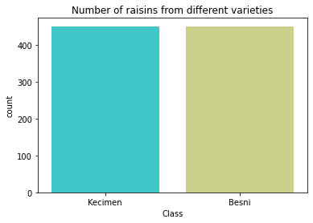

```python
#Showing the number of rasisns from different varieties on a plot
sns.countplot(x='Class',data=dF, palette='rainbow')
plt.title('Number of raisins from different varieties')
```

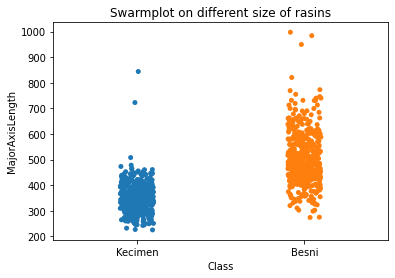

```python
#Plotting the Data for largest rasins
sns.stripplot(x='Class', y='MajorAxisLength', data=dF)
plt.title("Swarmplot on different size of rasins");
```

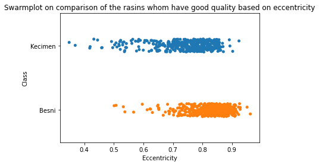

```python
#Plotting Data to compare the rasin whom have good quality
sns.stripplot(x='Eccentricity', y='Class', data=dF)
plt.title("Swarmplot on comparison of the rasins whom have good quality based on eccentricity");
```

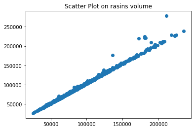

```python
#Plotting Data to compare the area and convex area of rasins
plt.scatter(dF['Area'],dF['ConvexArea'])
plt.title("Scatter Plot on rasins volume");
```

```python
#Counting the number of target variable
dF.groupby('Class').size()
```

```
Class
Besni      450
Kecimen    450
dtype: int64
```

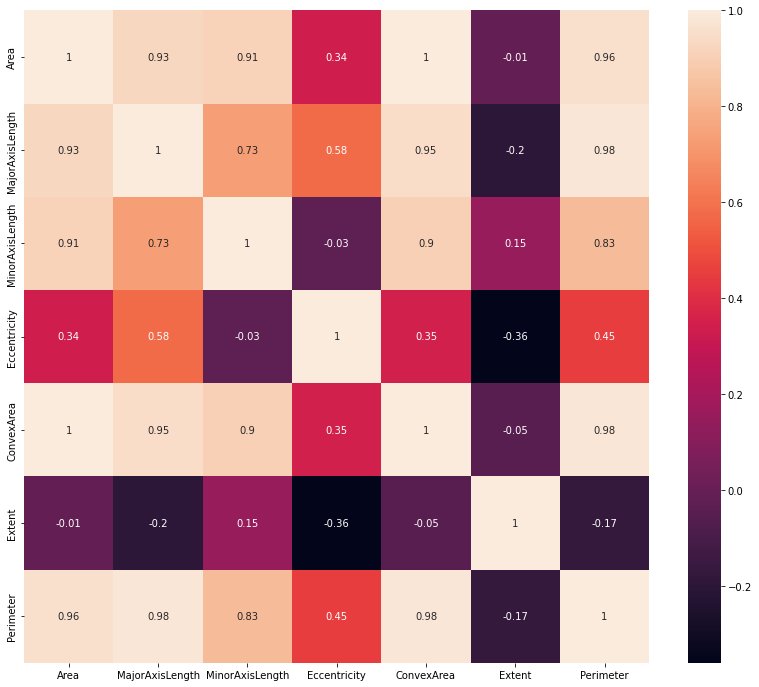

```python
# corr() to calculate the correlation between variables
from sklearn.model_selection import train_test_split
from sklearn.preprocessing import LabelEncoder
from sklearn.metrics import classification_report, confusion_matrix,precision_recall_curve, auc, roc_curve
from sklearn.tree import DecisionTreeClassifier, export_graphviz

correlation_matrix = dF.corr().round(2)
# changing the figure size
plt.figure(figsize = (14, 12))
# "annot = True" to print the values inside the square
sns.heatmap(data=correlation_matrix, annot=True)
```

```python
#creating the updated feature matrix using the important columns
up_df=dF[['Area','MajorAxisLength','MinorAxisLength','ConvexArea','Perimeter']]
up_df
```

|  | Area | MajorAxisLength | MinorAxisLength | ConvexArea | Perimeter |
| --- | --- | --- | --- | --- | --- |
| 0 | 87524 | 442.246011 | 253.291155 | 90546 | 1184.040 |
| 1 | 75166 | 406.690687 | 243.032436 | 78789 | 1121.786 |
| 2 | 90856 | 442.267048 | 266.328318 | 93717 | 1208.575 |
| 3 | 45928 | 286.540559 | 208.760042 | 47336 | 844.162 |
| 4 | 79408 | 352.190770 | 290.827533 | 81463 | 1073.251 |
| ... | ... | ... | ... | ... | ... |
| 895 | 83248 | 430.077308 | 247.838695 | 85839 | 1129.072 |
| 896 | 87350 | 440.735698 | 259.293149 | 90899 | 1214.252 |
| 897 | 99657 | 431.706981 | 298.837323 | 106264 | 1292.828 |
| 898 | 93523 | 476.344094 | 254.176054 | 97653 | 1258.548 |
| 899 | 85609 | 512.081774 | 215.271976 | 89197 | 1272.862 |

900 rows × 5 columns

```python
#seperating the target variable
y=dF['Class']
y
```

```
0      Kecimen
1      Kecimen
2      Kecimen
3      Kecimen
4      Kecimen
        ...
895      Besni
896      Besni
897      Besni
898      Besni
899      Besni
Name: Class, Length: 900, dtype: object
```

```python
from sklearn.model_selection import train_test_split
X_train, X_test, y_train, y_test = train_test_split(up_df, y, test_size = 0.3,random_state = 16)
print("X_train shape: ", X_train.shape)
print("X_test shape: ", X_test.shape)
print("y_train shape: ", y_train.shape)
print("y_test shape: ", y_test.shape)
```

```
X_train shape:  (630, 5)
X_test shape:  (270, 5)
y_train shape:  (630,)
y_test shape:  (270,)
```

Training: 630 out of 900 data has been chosen for training the model.

Testing: 270 out of 900 data has been chosen for testing the model.

This is a supervised machine learning model.

Because this is a labeled dataset and I know what type of data I am working with. Total 2 types of algorithms have been used to test the accuracy of this model. They are listed below:

1.Support Vector Machine algorithm

2.Decision Tree algorithm

Checking the Accuracy of the model based on Different ML Algorithms

```python
# importing the necessary package to use the svm algorithm
from sklearn import svm
model_svm = svm.SVC()
model_svm.fit(X_train, y_train)
y_prediction_svm = model_svm.predict(X_test)
score_svm = metrics.accuracy_score(y_prediction_svm, y_test).round(4)
print('The accuracy of the model based on Support Vector Machine Algorithm is {}%'.format(score_svm*100))
# perc.append(score_svm)
```

```
The accuracy of the model based on Support Vector Machine Algorithm is 83.7%
```

```python
# importing the necessary package to use the decision tree algorithm
from sklearn.tree import DecisionTreeClassifier
model_dt = DecisionTreeClassifier(random_state=4)
model_dt.fit(X_train, y_train)
y_prediction_dt = model_dt.predict(X_test)
score_dt = metrics.accuracy_score(y_prediction_dt, y_test).round(4)
print('The accuracy of the model based on Decision Tree Algorithm is {}%'.format(score_dt*100))
# perc.append(score_dt)
```

```
The accuracy of the model based on Decision Tree Algorithm is 82.22%
```

```python
# Example of getting neighbors for an instance
from math import sqrt

# calculate the Euclidean distance between two vectors
def euclidean_distance(row1, row2):
	distance = 0.0
	for i in range(len(row1)-1):
		distance += (row1[i] - row2[i])**2
	return sqrt(distance)

# Locate the most similar neighbors
def get_neighbors(train, test_row, num_neighbors):
	distances = list()
	for train_row in train:
		dist = euclidean_distance(test_row, train_row)
		distances.append((train_row, dist))
	distances.sort(key=lambda tup: tup[1])
	neighbors = list()
	for i in range(num_neighbors):
		neighbors.append(distances[i][0])
	return neighbors

# Test distance function
dataset = dF.values
neighbors = get_neighbors(dataset, dataset[0], 3)
for neighbor in neighbors:
	print(neighbor)
```

```
[87524 442.2460114 253.291155 0.819738392 90546 0.758650579 1184.04
 'Kecimen']
[87350 440.7356978 259.2931487 0.808628995 90899 0.636476246 1214.252
 'Besni']
[87252 433.4845202 261.0666438 0.798306516 90160 0.73579464 1166.517
 'Besni']
```

Model Accuracy:

This model has an accuracy of 83.7% based on Support Vector Machine algorithm.

```python
# Example of separating data by class value

# Split the dataset by class values, returns a dictionary
def separate_by_class(dataset):
	separated = dict()
	for i in range(len(dataset)):
		vector = dataset[i]
		class_value = vector[-1]
		if (class_value not in separated):
			separated[class_value] = list()
		separated[class_value].append(vector)
	return separated

separated = separate_by_class(dF.values)
for label in separated:
	print(label)
	for row in separated[label]:
		print(row)
```

[output not shown]

[output cut: 1734 more lines]

[output not shown]